# Assignment 10

```r
plda = predict(object = r3, # predictions
               newdata = df[-train, ])
head(plda$class)
```

```
## [1] Poor    Poor    Poor    Average Average Average
## Levels: Average Good Poor Very Good
```

```r
head(plda$posterior, 6) # posterior prob.
```

```
##     Average       Good      Poor    Very Good
## 1 0.1368207 0.01496714 0.8478357 0.0003765287
## 2 0.2986736 0.06852336 0.6287701 0.0040329589
## 3 0.3781985 0.09895590 0.5162910 0.0065545865
## 4 0.4316082 0.14455388 0.4111271 0.0127108716
## 5 0.4295730 0.21897906 0.3187007 0.0327472841
## 6 0.4691385 0.27328419 0.2118521 0.0457251460
```

```r
head(plda$x, 3)
```

```
##        LD1        LD2
## 1 2.425530  0.4560367
## 2 1.596919  0.1949101
## 3 1.388630 -0.3472952
```

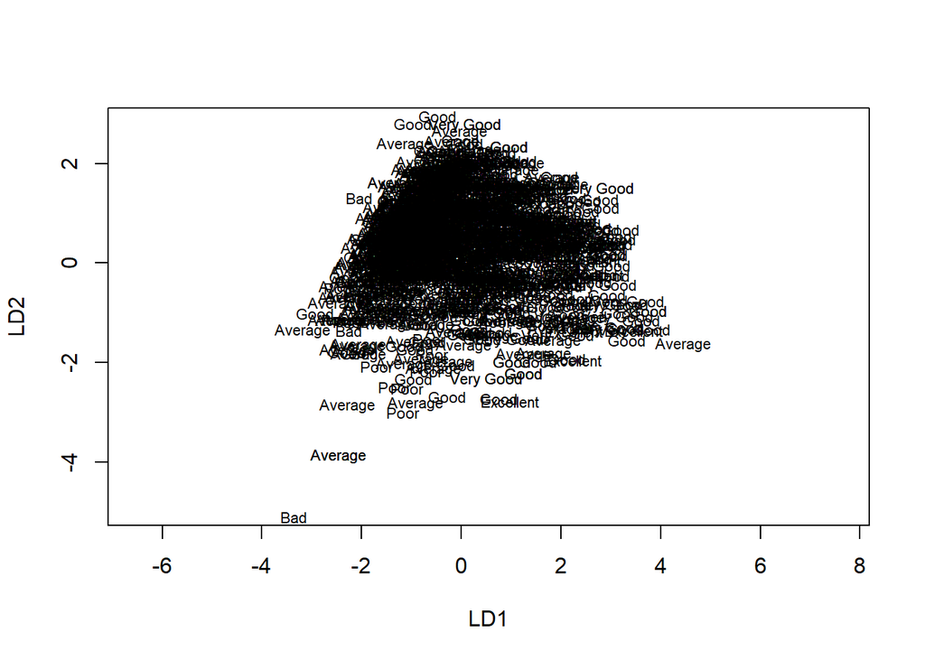

```r
plot(r)
```

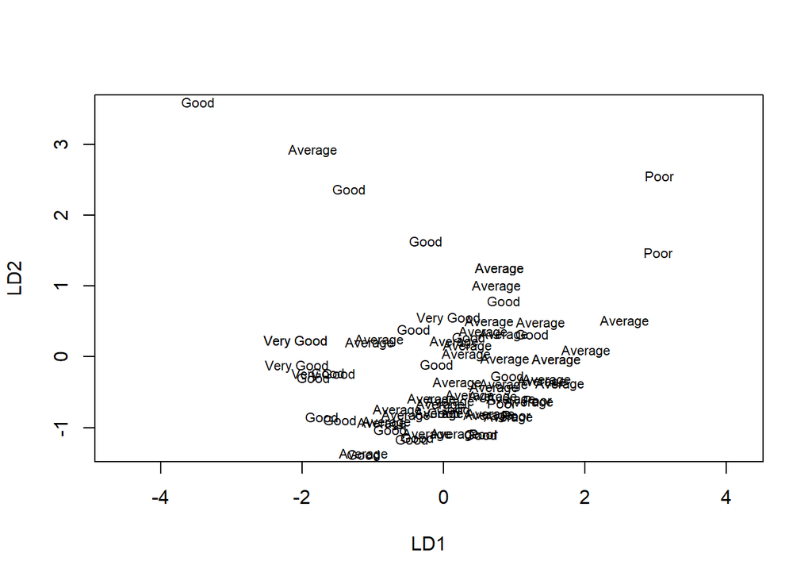

```r
plot(r3)
```

```r
r <- lda(quality ~ .,
         train_df,
         prior = prior)
prop.lda = r$svd^2/sum(r$svd^2)
plda <- predict(object = r,
                newdata = df)
```

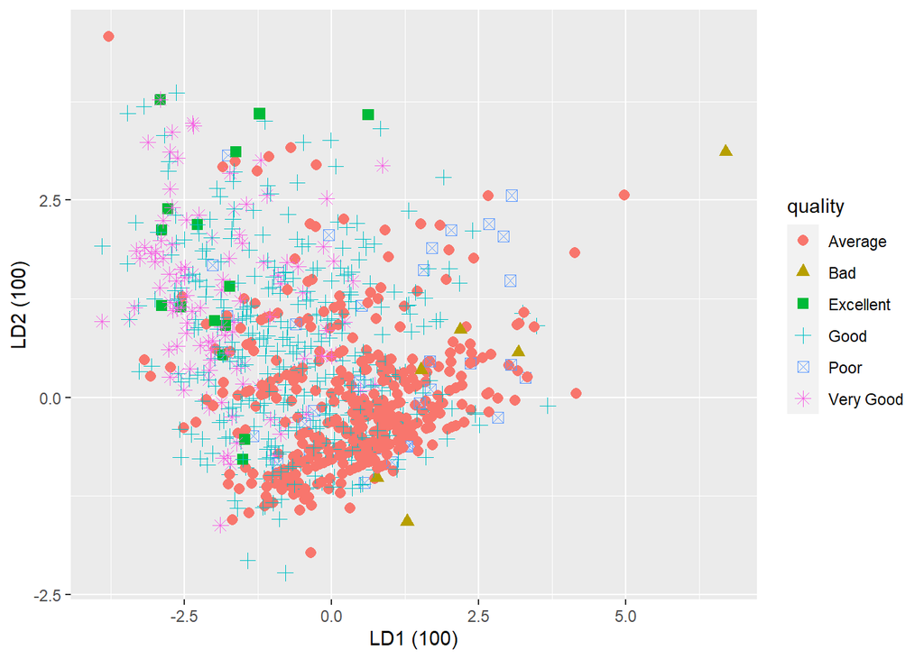

```r
dataset = data.frame(species = df[,"quality"],lda = plda$x)
ggplot(dataset) + geom_point(aes(lda.LD1, lda.LD2, colour = quality, shape = quality), size = 2.5) + labs(x = paste("LD1 (", percent(prop.lda[1]), ")", sep=""),y = paste("LD2 (", percent(prop.lda[2]), ")", sep=""))
```

```r
# lets play with accuracy
# lets look at another way to divide a dataset

set.seed(101) # Nothing is random!!
sample_n(df,10)
```

```
## # A tibble: 10 × 3
##    alcohol `volatile acidity` quality
##      <dbl>              <dbl> <chr>
##  1    12.4              0.33  Very Good
##  2     9.2              0.415 Average
##  3    10.5              0.51  Good
##  4    11.2              0.48  Average
##  5     9.2              0.58  Average
##  6     9.6              0.55  Average
##  7    11.1              0.34  Average
##  8     9                0.52  Good
##  9    10.2              0.45  Good
## 10     9.4              0.46  Average
```

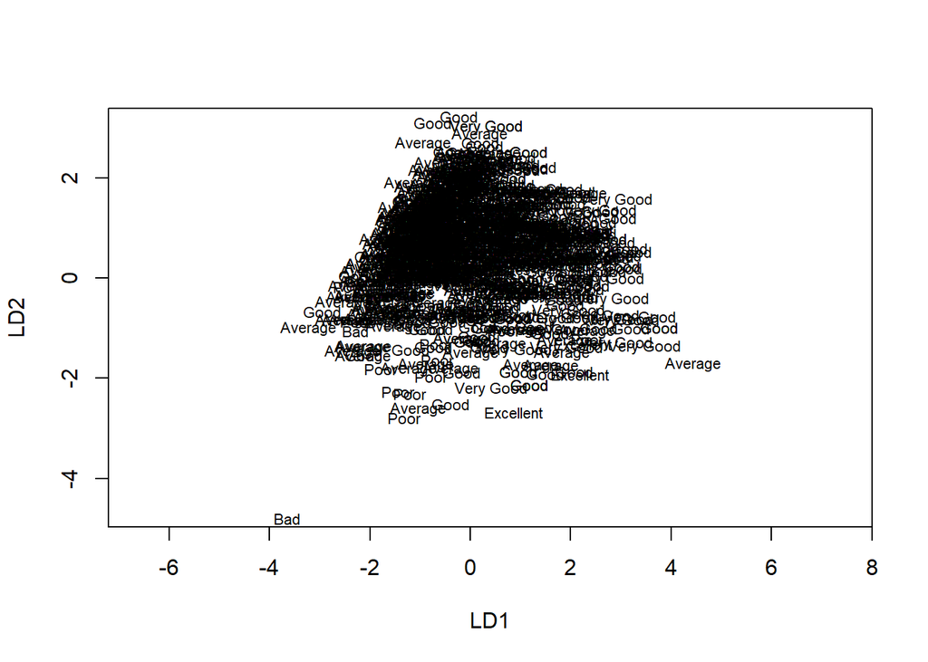

```r
# Lets take a sample of 75/25 like before. Dplyr preserves class.
training_sample <- sample(c(TRUE, FALSE), nrow(df), replace = T, prob = c(0.75,0.25))
train <- df[training_sample, ]
test <- df[!training_sample, ]
#lets run LDA like before
lda.df <- lda(quality ~ ., train)
# do a quick plot to understand how good the model is
plot(lda.df, col = as.integer(train$quality))
```

```r
# Sometime bell curves are better
# Set outer margin to zero
par(oma = c(0, 0, 0, 0))

# Set inner margin to a smaller value
par(mar = c(2, 2, 2, 2))
```

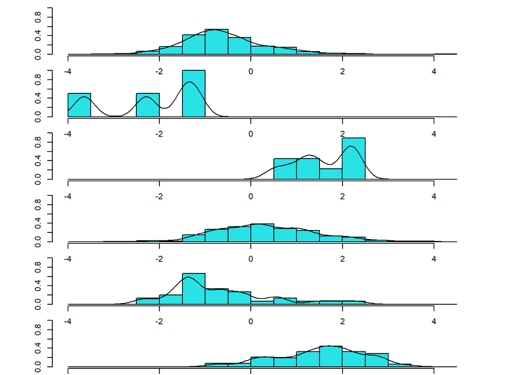

```r
# Set outer margin to zero
par(oma = c(0, 0, 0, 0))

# Set inner margin to a smaller value
par(mar = c(2, 2, 2, 2))

# Set the plot region directly
par(plt = c(0.1, 0.9, 0.1, 0.9))

# Plot the LDA result
plot(lda.df, dimen = 1, type = "b")
```

```r
# Reset plotting parameters
par(oma = c(0, 0, 0, 0))
par(mar = c(5, 4, 4, 2) + 0.1)  # Reset to default values
```

```r
attach(train)
train
```

```
## # A tibble: 861 × 3
##    alcohol `volatile acidity` quality
##      <dbl>              <dbl> <chr>
##  1     9.8              0.88  Average
##  2     9.8              0.76  Average
##  3     9.4              0.66  Average
##  4     9.4              0.6   Average
##  5    10                0.65  Very Good
##  6     9.5              0.58  Very Good
##  7     9.2              0.58  Average
##  8     9.9              0.615 Average
##  9     9.1              0.61  Average
## 10    10.5              0.28  Very Good
## # ℹ 851 more rows
```

3. Residual Analysis (2 points)

The residual analysis for the predictor variable “volatile acidity” reveals significant variability in the response variable “quality” that is not explained by this predictor.

The residual sum of squares (SS) is 30.4343, indicating the total unexplained variability in the response variable after accounting for “volatile acidity.”

The mean square (MS) represents the average unexplained variability per degree of freedom, which is 0.02677.

The associated F-value (F) is 47.938, indicating that there is a significant difference in the mean response variable among the groups defined by “quality.”

The p-value (Pr(>F)) is less than 2.2e-16, indicating strong evidence against the null hypothesis. This suggests that “volatile acidity” significantly influences the quality of the product.

Overall, the residual analysis underscores the importance of “volatile acidity” as a predictor of product quality. However, it also implies that other factors not included in the model may contribute to the remaining variability in product quality.

Further investigation or refinement of the model may be necessary to capture these additional influences.

5. Model Accuracy (2 points) Df (Degrees of Freedom): For the factor “quality”: 5 degrees of freedom, representing the number of quality levels minus 1.

For residuals: 1137 degrees of freedom, representing the error or unexplained variability.

Sum Sq (Sum of Squares):

For the factor “quality”: 356.83, which is the variability in alcohol content explained by the quality levels. For residuals: 980.62, which is the unexplained variability or error.

Mean Sq (Mean Square):

For the factor “quality”: 71.366, which is the average amount of variability in alcohol content explained by the quality levels.

For residuals: 0.862, which is the average amount of unexplained variability or error.

F value (F-statistic):

This value tests the null hypothesis that there is no relationship between alcohol content and quality levels. The obtained F value of 82.747 is highly significant (p < 0.05), indicating strong evidence against the null hypothesis.

Pr(>F) (p-value):

This is the probability of observing an F statistic as extreme as the one obtained if the null hypothesis were true.

The very small p-value (< 2.2e-16) indicates strong evidence against the null hypothesis, suggesting a significant relationship between alcohol content and quality levels.

Overall, the ANOVA results suggest that alcohol content significantly influences the quality levels of the observations.

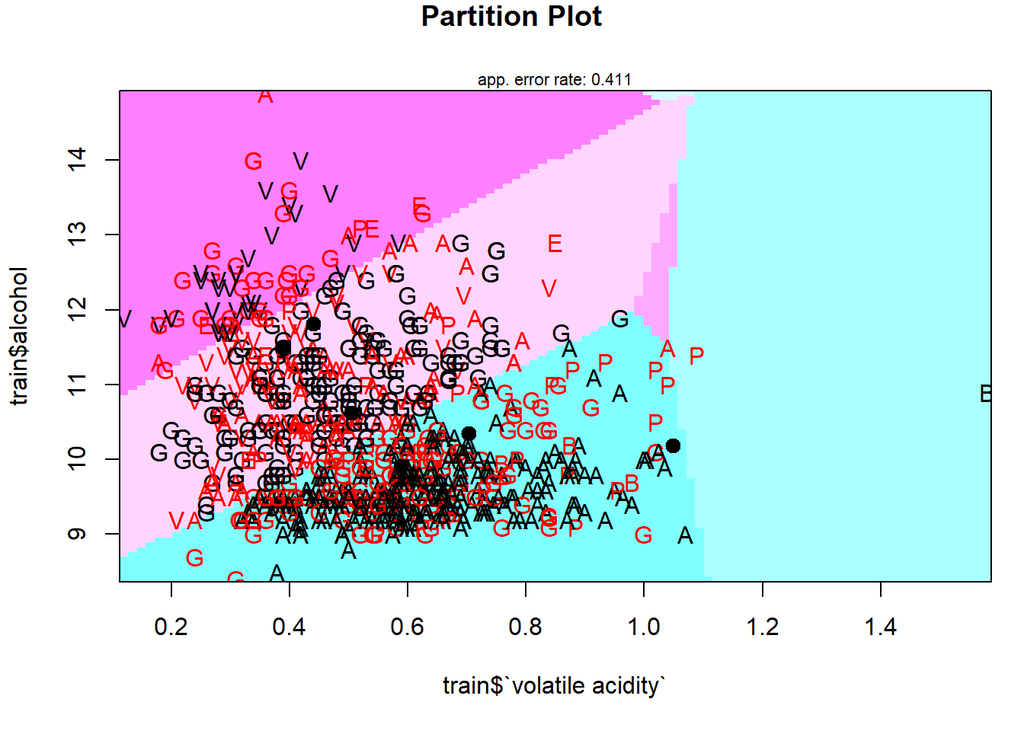

```r
# Reset to default values
# THis plot shows the essense of LDA. It puts everything on a line and finds cutoffs.
# Partition plots
# Print the column names of the train data frame
train$quality <- factor(train$quality)

partimat(train$quality ~ train$alcohol + train$`volatile acidity` , data=train, method="lda")
```

```r
# Lets focus on accuracy. Table function
lda.train <- predict(lda.df)
train$lda <- lda.train$class
table(train$lda,train$quality)
```

```
##
##             Average Bad Excellent Good Poor Very Good
##   Average       283   3         0  132   22         5
##   Bad             1   1         0    0    1         0
##   Excellent       0   0         0    0    0         0
##   Good           77   0         5  186    6        62
##   Poor            0   0         0    0    0         0
##   Very Good       4   0         4   31    1        37
```

```r
# running accuracy on the training set shows how good the model is. It is not an indication of "true" accuracy. We will use the test set to approximate accuracy
lda.test <- predict(lda.df,test)
test$lda <- lda.test$class
table(test$lda,test$quality)
```

```
##
##             Average Bad Excellent Good Poor Very Good
##   Average        92   2         0   44    3         1
##   Bad             3   0         0    0    0         0
##   Excellent       0   0         0    0    0         0
##   Good           22   0         3   54    0        24
##   Poor            0   0         0    0    0         0
##   Very Good       1   0         4   15    0        14
```

```r
# Wilk's Lambda and F test for each variablw
m <- manova(cbind(alcohol,`volatile acidity`)~quality,data=df)
summary(m,test="Wilks")
```

```
##             Df   Wilks approx F num Df den Df    Pr(>F)
## quality      5 0.63168   58.665     10   2272 < 2.2e-16 ***
## Residuals 1137
## ---
## Signif. codes:  0 '***' 0.001 '**' 0.01 '*' 0.05 '.' 0.1 ' ' 1
```

```r
summary(m,test="Pillai")
```

```
##             Df  Pillai approx F num Df den Df    Pr(>F)
## quality      5 0.37817   53.024     10   2274 < 2.2e-16 ***
## Residuals 1137
## ---
## Signif. codes:  0 '***' 0.001 '**' 0.01 '*' 0.05 '.' 0.1 ' ' 1
```

```r
summary.aov(m)
```

```
##  Response alcohol :
##               Df Sum Sq Mean Sq F value    Pr(>F)
## quality        5 356.83  71.366  82.747 < 2.2e-16 ***
## Residuals   1137 980.62   0.862
## ---
## Signif. codes:  0 '***' 0.001 '**' 0.01 '*' 0.05 '.' 0.1 ' ' 1
##
##  Response volatile acidity :
##               Df  Sum Sq Mean Sq F value    Pr(>F)
## quality        5  6.4158 1.28317  47.938 < 2.2e-16 ***
## Residuals   1137 30.4343 0.02677
## ---
## Signif. codes:  0 '***' 0.001 '**' 0.01 '*' 0.05 '.' 0.1 ' ' 1
```